# Model assumptions

# 7 `performance` package

- the `performance` package has a nice function `check_model()` that produces 6 plots to check model fit

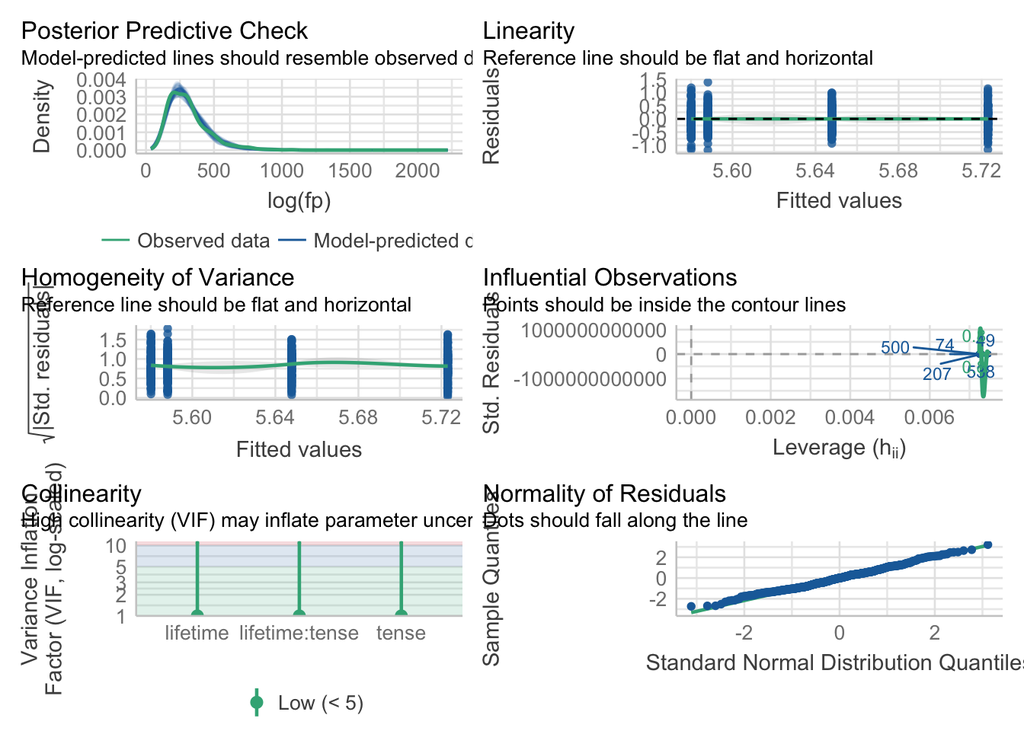

Figure 2: Performance of model with log reading times

```r
performance::check_model(fit_fp_log)
```

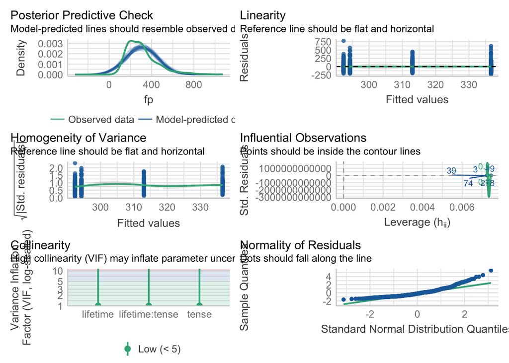

```r
performance::check_model(fit_fp)
```

# 8 Communicating your results

- model summaries can be provided via tables and/or figures
  - you should always report the t-values and p-values of an effect
- this is where the `tidy()` function from `broom` is handy in combination with `knitr::kable(digits = x)` and `kableExtra::kable_styling()`

```r
tidy(fit_fp_log) %>%
  kable(digits = 10,
        col.names = c("Coefficient",
                      "Estimate (log)",
                      "SE",
                      "t-value",
                      "p-value")) %>%
  kable_styling()
```

| Coefficient | Estimate (log) | SE | t-value | p-value |
| --- | --- | --- | --- | --- |
| (Intercept) | 5.63476711 | 0.01877047 | 300.1931843 | 0.000000000 |
| lifetime1 | 0.10130415 | 0.03754094 | 2.6984981 | 0.007183743 |
| tense1 | -0.03357132 | 0.03754094 | -0.8942589 | 0.371582493 |
| lifetime1:tense1 | -0.08320391 | 0.07508188 | -1.1081757 | 0.268280198 |

## 8.1 P-value formatting

- you can create a function the replaces p-values

```r
# source: https://stackoverflow.com/questions/37470202/in-line-code-for-reporting-p-values-001-in-r-markdown
# OR USE
pacman::p_load(broman)
format_pval <- function(x){
  if (x < .001) return(paste('<', '.001'))
  if (x < .01) return(paste('<', '.01'))
  if (x < .05) return(paste('<', '.05'))
  paste('=', myround(x, 3))  # if above .05, print p-value to 3 decimalp points
}
```

```r
make_stars <- function(pval) {
  stars = ""
  if(pval <= 0.001)
    stars = "***"
  if(pval > 0.001 & pval <= 0.01)
    stars = "**"
  if(pval > 0.01 & pval <= 0.05)
    stars = "*"
  if(pval > 0.05 & pval <= 0.1)
     stars = "."
  stars
}
```

## 8.2 Formatted table

```r
tidy(fit_fp_log) %>%
  mutate(format = sapply(p.value, function(x) format_pval(x))) %>%
  mutate(signif = sapply(p.value, function(x) make_stars(x))) %>%
  select(-p.value) %>%
  kable(digits = 10,
        col.names = c("Coefficient",
                      "Estimate (log)",
                      "SE",
                      "t-value",
                      "p-value",
                      "sign")) %>%
  kable_styling()
```

| Coefficient | Estimate (log) | SE | t-value | p-value | sign |
| --- | --- | --- | --- | --- | --- |
| (Intercept) | 5.63476711 | 0.01877047 | 300.1931843 | < .001 | *** |
| lifetime1 | 0.10130415 | 0.03754094 | 2.6984981 | < .01 | ** |
| tense1 | -0.03357132 | 0.03754094 | -0.8942589 | = 0.372 |  |
| lifetime1:tense1 | -0.08320391 | 0.07508188 | -1.1081757 | = 0.268 |  |

## 8.3 Plots

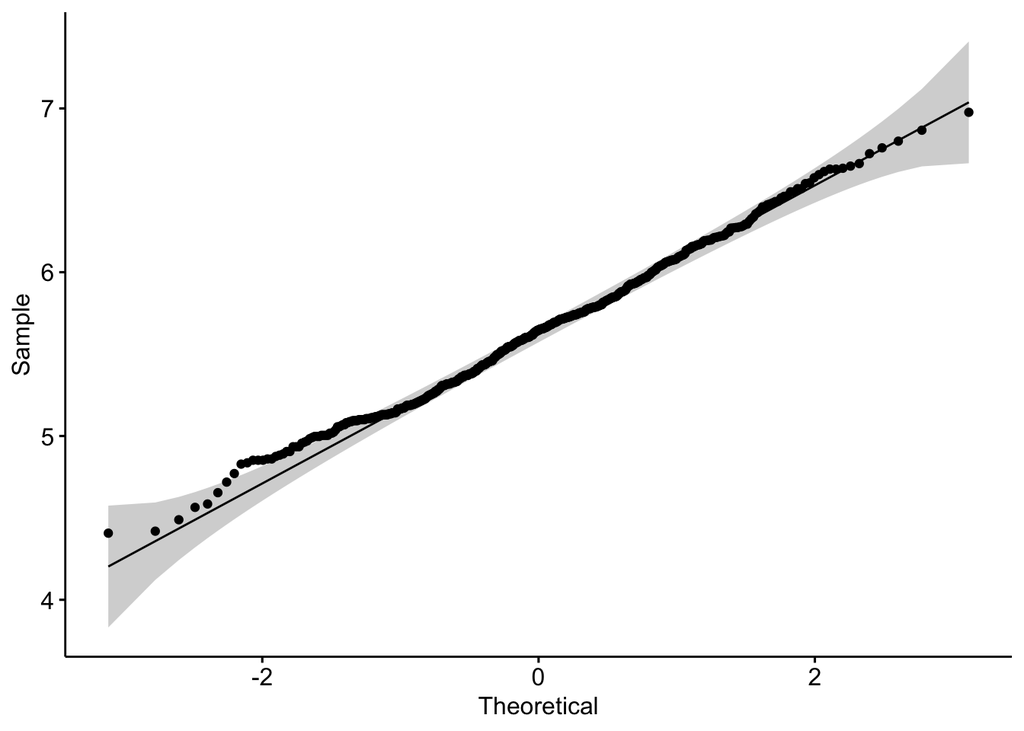

```r
df_crit_verb |>
  filter(fp > 0) |>
  mutate(log_ff = log(fp)) |>
  mutate(half = if_else(trial >= 104, "1st","2nd")) |>
  ggpubr::ggqqplot(x = "log_ff")
```

### 8.3.1 sjPlot

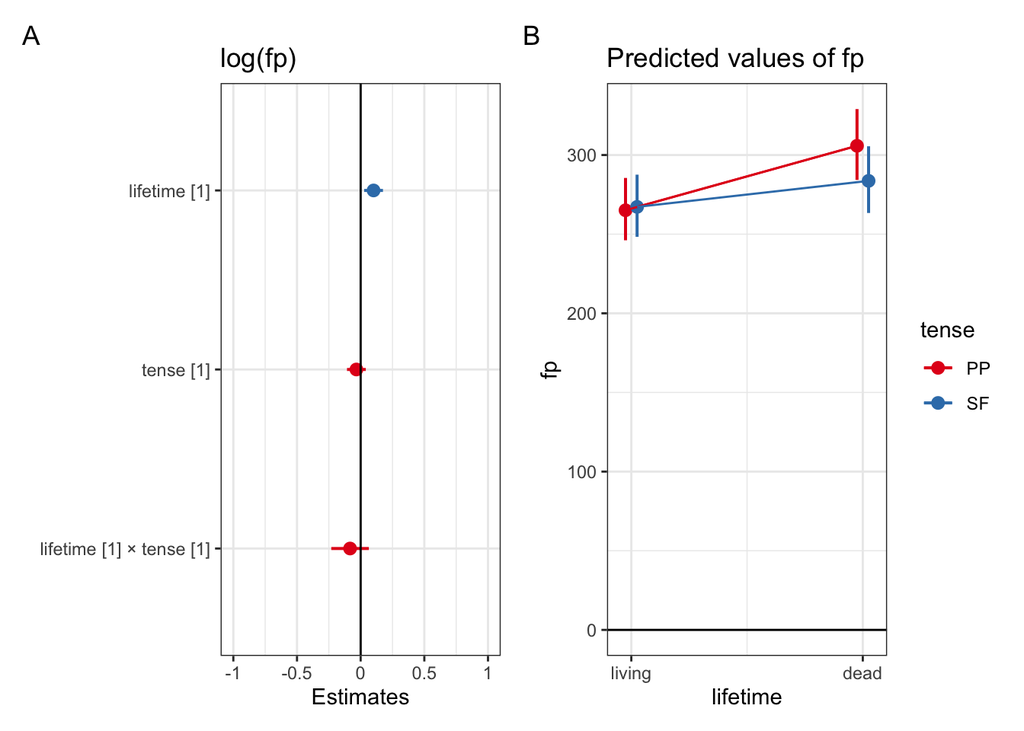

### 8.3.2 Distributions

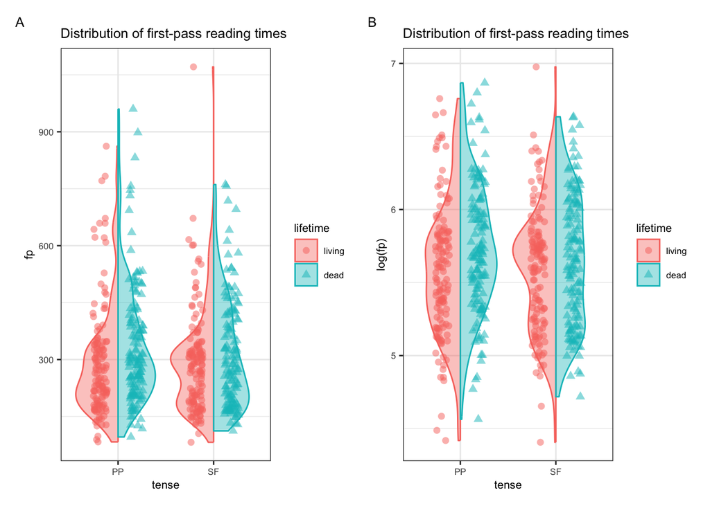

### 8.3.3 Errorbar

```r
fig_error <-
  df_crit_verb %>%
  filter(fp > 0) %>%
  summarySEwithin(measurevar="fp", withinvars=c("lifetime", "tense"), idvar="px") %>%
  mutate(upper = fp+ci,
         lower = fp-ci) %>%
  ggplot(aes(x = lifetime, y = fp, colour = tense, shape = tense)) +
  labs(title = "Mean first-pass reading times (with 95% CIs)") +
  geom_point(position = position_dodge(0.2), size = 2) +
  geom_line(position = position_dodge(0.2), aes(group=tense)) +
  geom_errorbar(aes(ymin=lower,ymax=upper), position = position_dodge(0.2), width = .2) +
  theme_bw() +
  theme(text = element_text(size=8))

fig_error_log <-
  df_crit_verb %>%
  filter(fp > 0) %>%
  mutate(fp_log = log(fp)) %>%
  summarySEwithin(measurevar="fp_log", withinvars=c("lifetime", "tense"), idvar="px") %>%
  mutate(upper = fp_log+ci,
         lower = fp_log-ci) %>%
  ggplot(aes(x = lifetime, y = fp_log, colour = tense, shape = tense)) +
  labs(title = "Mean first-pass reading times (with 95% CIs)") +
  geom_point(position = position_dodge(0.2), size = 2) +
  geom_line(position = position_dodge(0.2), aes(group=tense)) +
  geom_errorbar(aes(ymin=lower,ymax=upper), position = position_dodge(0.2), width = .2) +
  theme_bw() +
  theme(text = element_text(size=8))
```

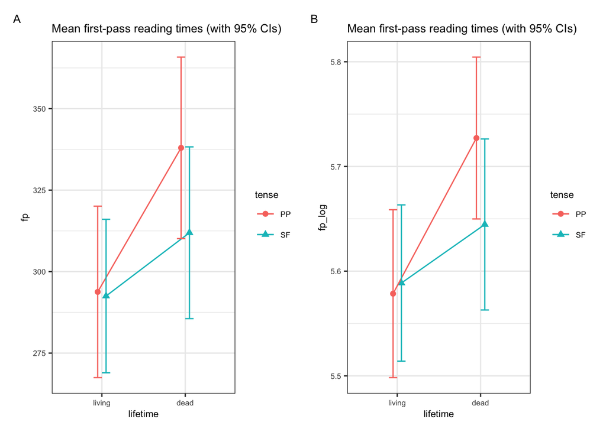

# 9 Summary

- we looked at some assumptions of linear models and how to check them
- we saw how to log-transform our data so that our residuals are normally distributed
- we learned the importance of the independence assumption, which is violated by repeated-measures designs
- next, we’ll learn how to account for lack of independence between the data with mixed models

# References

Winter, B. (2019). *Statistics for Linguists: An Introduction Using R*. Routledge. https://doi.org/10.4324/9781315165547